# individual2

Cody Nielsen

9/27/2020

## Exploring General Social Survey

Load data

```r
library(tidyverse)
dat <- readxl::read_xls('GSS.xls')
dat
```

```
## # A tibble: 64,816 x 5
##    `Marital status` `Highest year o~ `Respondents se~ `Political part~
##    <chr>            <chr>            <chr>            <chr>
##  1 Never married    16               Female           Ind,near dem
##  2 Married          10               Male             Not str democrat
##  3 Married          12               Female           Independent
##  4 Married          17               Female           Not str democrat
##  5 Married          12               Female           Strong democrat
##  6 Never married    14               Male             Ind,near dem
##  7 Divorced         13               Male             Ind,near dem
##  8 Never married    16               Male             Ind,near dem
##  9 Never married    12               Female           Strong democrat
## 10 Married          12               Female           Strong democrat
## # ... with 64,806 more rows, and 1 more variable: `General happiness` <chr>
```

Clean data

```r
dat_clean <- dat %>% rename(marital_status='Marital status', years_school='Highest year of school completed', sex='Respondents sex', pol_party='Political party affiliation', happy_lvl='General happiness')
names(dat_clean)
```

```
## [1] "marital_status" "years_school"   "sex"            "pol_party"
## [5] "happy_lvl"
```

```r
dat_clean
```

```
## # A tibble: 64,816 x 5
##    marital_status years_school sex    pol_party        happy_lvl
##    <chr>          <chr>        <chr>  <chr>            <chr>
##  1 Never married  16           Female Ind,near dem     Not too happy
##  2 Married        10           Male   Not str democrat Not too happy
##  3 Married        12           Female Independent      Pretty happy
##  4 Married        17           Female Not str democrat Not too happy
##  5 Married        12           Female Strong democrat  Pretty happy
##  6 Never married  14           Male   Ind,near dem     Pretty happy
##  7 Divorced       13           Male   Ind,near dem     Not too happy
##  8 Never married  16           Male   Ind,near dem     Not too happy
##  9 Never married  12           Female Strong democrat  Pretty happy
## 10 Married        12           Female Strong democrat  Pretty happy
## # ... with 64,806 more rows
```

```r
dat_clean <- transform(dat_clean, years_school = as.numeric(years_school))
class(dat_clean$years_school)
```

```
## [1] "numeric"
```

1.Find the average years of education for the respondents with each political party affiliation. Arrange your output in a meaningful order and print. Describe any patterns you find.

```r
dat1 <-aggregate(years_school~pol_party, dat_clean, mean)
dat1<- dat1[order(dat1$years_school,decreasing=T),]
dat1
```

```
##             pol_party years_school
## 10  Strong republican     13.44067
## 8         Other party     13.43324
## 3        Ind,near rep     13.29531
## 7  Not str republican     13.25678
## 2        Ind,near dem     13.20671
## 6    Not str democrat     12.61759
## 9     Strong democrat     12.47403
## 4         Independent     12.31946
## 5           No answer     12.27913
## 1          Don't know     10.90909
```

2.Create a single data frame containing records for the better educated respondents in each political party affiliation. A “better educated” respondent is someone who has strictly more years of education than the median in the same party affiliation. Print the structure of the data frame.

```r
#dat2 <-aggregate(years_school~pol_party, dat_clean, median)
#dat2 <- dat_clean %>% filter (years_school>median(years_school))
#str(dat2)
dat2 <-dat_clean %>%
  select(years_school, pol_party) %>%
  group_by(pol_party) %>%
  filter(years_school > median(years_school, na.rm = TRUE))
str(dat2)
```

```
## tibble [27,840 x 2] (S3: grouped_df/tbl_df/tbl/data.frame)
##  $ years_school: num [1:27840] 16 17 14 16 13 14 14 17 14 16 ...
##  $ pol_party   : chr [1:27840] "Ind,near dem" "Not str democrat" "Ind,near dem" "Ind,near dem" ...
##  - attr(*, "groups")= tibble [10 x 2] (S3: tbl_df/tbl/data.frame)
##   ..$ pol_party: chr [1:10] "Don't know" "Ind,near dem" "Ind,near rep" "Independent" ...
##   ..$ .rows    : list<int> [1:10]
##   .. ..$ : int [1:5] 837 1083 1137 1262 23661
##   .. ..$ : int [1:3257] 1 3 4 8 16 19 27 35 41 47 ...
##   .. ..$ : int [1:2456] 7 9 11 21 43 53 56 58 59 68 ...
##   .. ..$ : int [1:3852] 23 29 45 48 49 57 62 78 79 102 ...
##   .. ..$ : int [1:148] 299 519 689 897 1007 1102 1191 1482 1513 1648 ...
##   .. ..$ : int [1:5692] 2 13 15 25 28 31 36 38 44 46 ...
##   .. ..$ : int [1:4322] 14 18 20 24 30 33 42 52 65 71 ...
##   .. ..$ : int [1:520] 22 26 61 89 99 111 151 154 192 376 ...
##   .. ..$ : int [1:4537] 5 6 12 17 37 39 40 74 75 76 ...
##   .. ..$ : int [1:3051] 10 32 34 50 51 64 66 88 100 127 ...
##   .. ..@ ptype: int(0)
##   ..- attr(*, ".drop")= logi TRUE
```

3.How is the happiness of a respondent related to his/her marriage status? Define that a person is happy if the response to question is “Very happy” or “Pretty happy”.

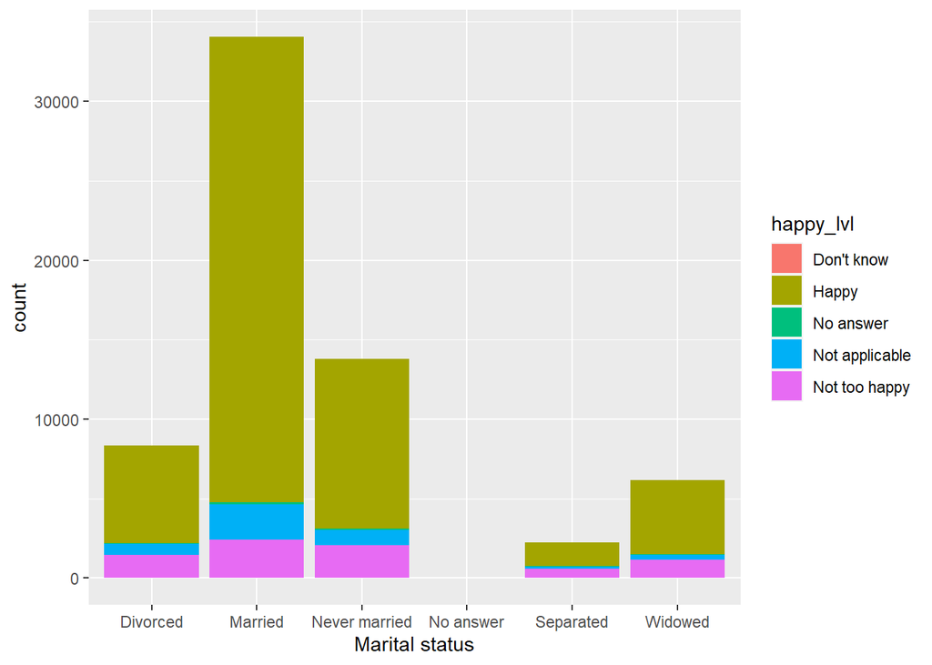

```r
dat_clean$happy_lvl <- sub('Very happy', 'Happy', dat_clean$happy_lvl)
dat_clean$happy_lvl <- sub('Pretty happy', 'Happy', dat_clean$happy_lvl)
dat_clean<-na.omit(dat_clean)
ggplot(dat_clean, aes(x=marital_status, fill=happy_lvl))+geom_bar()+xlab("Marital status")
```

Looks like people are more happy married.

4.Does party affiliation affect the relationship you found in the last question?

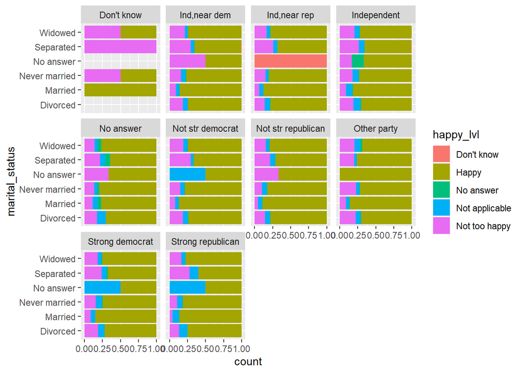

```r
dat3 <-dat_clean %>% select(marital_status,happy_lvl, pol_party)
g <- ggplot(data = dat3, aes(x = marital_status, fill = happy_lvl)) + geom_bar(position = "fill") +coord_flip()+facet_wrap(~pol_party)
g
```

Doesn’t look like political party affiliation has any effect, people seem generally happy.

5.How is marital status related to the education of a respondent? What are possible reasons accounting for the patterns you see?

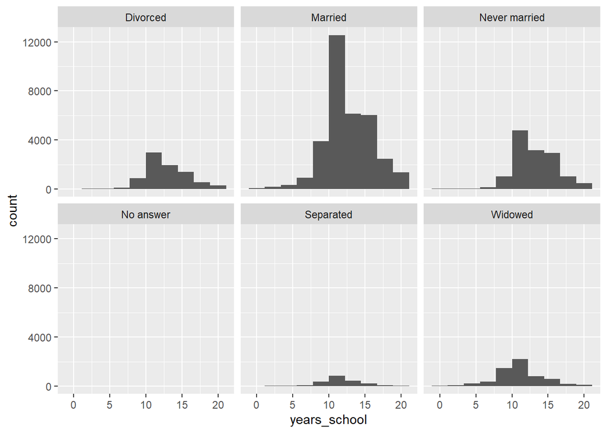

```r
ggplot(dat_clean, aes(years_school)) + facet_wrap(~marital_status)+geom_histogram(bins=10)
```

It looks the highest frequency of educated people are married. The frequency of education is lower for separated couples. This could be because educated couples make better decisions.

6.Explore two more interesting questions, and answer those questions using the GSS data.